# Modelo Beta-Binomial Hierárquico

Simulação e Inferência Posterior

## Especificação do modelo

O modelo Beta-Binomial hierárquico assume a seguinte estrutura:

$$Y_i \mid \theta_i \sim \text{Binomial}(n_i, \theta_i), \quad i = 1, \ldots, N$$

$$\theta_i \mid \omega, \kappa \sim \text{Beta}(\alpha, \beta)$$

$$\omega \sim \text{Beta}(a, b)$$

onde $\kappa$ é tratado como fixado. A reparametrização por moda e concentração relaciona $(\alpha, \beta)$ com $(\omega, \kappa)$:

$$\omega = \frac{\alpha - 1}{\alpha + \beta - 2}, \qquad \kappa = \alpha + \beta$$

de modo que

$$\alpha = (\kappa - 2)\,\omega + 1, \qquad \beta = (\kappa - 2)\,(1 - \omega) + 1.$$

Aqui, $\omega$ representa a moda da distribuição populacional dos $\theta_i$ e $\kappa$ controla a concentração em torno dessa moda.

## Simulação dos dados

Os dados são gerados seguindo a estrutura hierárquica do modelo. Primeiro, amostramos $\omega$ da priori $\text{Beta}(a, b)$. Em seguida, calculamos $\alpha$ e $\beta$ pela reparametrização e simulamos os parâmetros individuais $\theta_i$ e, por fim, as observações $Y_i$.

```r
library(tidyverse)
library(patchwork)
theme_set(theme_bw())

set.seed(42)
```

```r
## Parâmetros fixados
N <- 8 # número de observações
kappa <- 20 # concentração (fixada)
a <- 2 # hiperparâmetro da prior de omega
b <- 2 # hiperparâmetro da prior de omega
(n <- sample(10:50, N, replace = TRUE)) # tamanhos amostrais n_i
```

```
[1] 46 10 34 19 45 27 33 16
```

```r
## Passo 1: Simular w ~ Beta(a, b)
(w <- rbeta(1, shape1 = a, shape2 = b))
```

```
[1] 0.3194048
```

```r
## Passo 2: Calcular alpha e beta via reparametrização
alpha_par <- (kappa - 2) * w + 1
beta_par <- (kappa - 2) * (1 - w) + 1
c(alpha = alpha_par, beta = beta_par)
```

```
    alpha      beta
 6.749286 13.250714
```

```r
## Passo 3: Simular theta_i ~ Beta(alpha, beta)
theta <- rbeta(N, shape1 = alpha_par, shape2 = beta_par)

## Passo 4: Simular Y_i ~ Binomial(n_i, theta_i)
y <- rbinom(N, size = n, prob = theta)

## Dataset resultante
da <- tibble(
  i = 1:N,
  n_i = n,
  theta_i = theta,
  y_i = y,
  prop = y/n
)
```

Os dados simulados são apresentados abaixo. A coluna `prop` contém a proporção observada $\hat{p}_i = y_i / n_i$.

```r
da
```

```
# A tibble: 8 × 5
      i   n_i theta_i   y_i  prop
  <int> <int>   <dbl> <int> <dbl>
1     1    46   0.205    12 0.261
2     2    10   0.356     0 0
3     3    34   0.573    22 0.647
4     4    19   0.342     9 0.474
5     5    45   0.522    23 0.511
6     6    27   0.468    12 0.444
7     7    33   0.454    15 0.455
8     8    16   0.398     3 0.188
```

### Visualização da simulação

O painel esquerdo mostra a priori $\omega \sim \text{Beta}(a, b)$ com o valor simulado (linha vermelha). O painel central mostra a densidade $\text{Beta}(\alpha, \beta)$ da qual os $\theta_i$ foram sorteados (pontos vermelhos). O painel direito compara os verdadeiros $\theta_i$ com as proporções observadas $\hat{p}_i$.

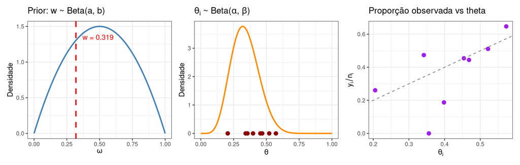

Figura 1

## Inferência posterior — Modelo hierárquico

Nos modelos a seguir, $\kappa = 20$ é tratado como fixado. O objetivo é inferir a moda populacional $\omega$ e os parâmetros individuais $\theta_i$.

Nos gráficos, o ponto/linha azul representa a estimativa posterior (média), a linha pontilhada azul indica a média posterior de $\omega$, e o $\times$ vermelho marca o valor verdadeiro simulado.

### JAGS

No JAGS, $\omega$ e cada $\theta_i$ são amostrados explicitamente via MCMC. O parâmetro $\kappa$ é passado como dado.

Resumo das estatísticas posteriores (JAGS):

```
              Mean         SD     Naive SE Time-series SE
omega    0.3915665 0.05518700 0.0004506000   0.0009023320
theta[1] 0.3033539 0.05718258 0.0004668938   0.0006323449
theta[2] 0.2680786 0.08601996 0.0007023500   0.0011032047
theta[3] 0.5558269 0.07012064 0.0005725327   0.0007764277
theta[4] 0.4367178 0.08302786 0.0006779197   0.0009825717
theta[5] 0.4769087 0.06308557 0.0005150915   0.0007446719
theta[6] 0.4261183 0.07438395 0.0006073424   0.0008358378
theta[7] 0.4344975 0.06990150 0.0005707433   0.0007992912
theta[8] 0.3083573 0.08126922 0.0006635604   0.0009767386
```

Estimativas posteriores dos $\theta_i$ com intervalos de credibilidade de 95%:

```
# A tibble: 8 × 7
      i   n_i   y_i theta_i mean_post lower upper
  <int> <int> <int>   <dbl>     <dbl> <dbl> <dbl>
1     1    46    12   0.205     0.303 0.196 0.421
2     2    10     0   0.356     0.268 0.119 0.453
3     3    34    22   0.573     0.556 0.417 0.691
4     4    19     9   0.342     0.437 0.279 0.603
5     5    45    23   0.522     0.477 0.356 0.599
6     6    27    12   0.468     0.426 0.285 0.576
7     7    33    15   0.454     0.434 0.300 0.573
8     8    16     3   0.398     0.308 0.163 0.482
```

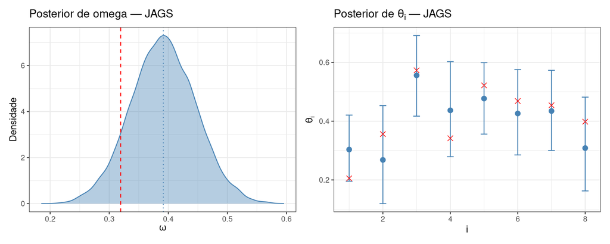

Figura 2

### Stan

O Stan estima $\omega$ e $\theta_i$ como parâmetros, com $\alpha$ e $\beta$ calculados no bloco `transformed parameters`.

Resumo dos parâmetros populacionais (Stan):

```
Inference for Stan model: anon_model.
3 chains, each with iter=4000; warmup=1000; thin=1;
post-warmup draws per chain=3000, total post-warmup draws=9000.

           mean se_mean   sd 2.5%   25%   50%   75% 97.5% n_eff Rhat
omega      0.39    0.00 0.06 0.28  0.35  0.39  0.43  0.50  9214    1
alpha_par  8.05    0.01 1.00 6.08  7.37  8.04  8.71 10.02  9214    1
beta_par  11.95    0.01 1.00 9.98 11.29 11.96 12.63 13.92  9214    1

Samples were drawn using NUTS(diag_e) at Wed Mar 25 21:14:30 2026.
For each parameter, n_eff is a crude measure of effective sample size,
and Rhat is the potential scale reduction factor on split chains (at
convergence, Rhat=1).
```

Resumo completo:

```
                  mean      se_mean         sd         2.5%          25%
omega        0.3914937 0.0005778848 0.05547175    0.2821015    0.3540462
theta[1]     0.3037390 0.0004807565 0.05859146    0.1928141    0.2633462
theta[2]     0.2683474 0.0007568800 0.08667727    0.1162772    0.2058847
theta[3]     0.5566788 0.0005575710 0.06887388    0.4193662    0.5105903
theta[4]     0.4368292 0.0006927684 0.08189060    0.2782478    0.3801587
theta[5]     0.4777244 0.0005176590 0.06331711    0.3539386    0.4344812
theta[6]     0.4264163 0.0006629314 0.07506989    0.2821794    0.3751180
theta[7]     0.4341967 0.0005591783 0.07032628    0.2981355    0.3866304
theta[8]     0.3067798 0.0007003285 0.08060128    0.1601622    0.2491753
alpha_par    8.0468859 0.0104019264 0.99849157    6.0778271    7.3728311
beta_par    11.9531141 0.0104019264 0.99849157    9.9754252   11.2935305
lp__      -158.1190617 0.0341722596 2.17876438 -163.2563427 -159.3970877
                   50%          75%        97.5%     n_eff      Rhat
omega        0.3910284    0.4281372    0.5013653  9214.277 1.0001456
theta[1]     0.3016535    0.3426389    0.4231404 14853.139 0.9998779
theta[2]     0.2622097    0.3240079    0.4552193 13114.641 1.0000111
theta[3]     0.5569401    0.6040399    0.6878695 15258.390 0.9997493
theta[4]     0.4363420    0.4921073    0.5979500 13973.072 1.0000399
theta[5]     0.4769579    0.5209598    0.5985619 14960.794 0.9998307
theta[6]     0.4255054    0.4760301    0.5759792 12823.141 0.9998393
theta[7]     0.4333382    0.4811060    0.5750683 15817.383 0.9999405
theta[8]     0.3037443    0.3586832    0.4738452 13245.864 0.9997781
alpha_par    8.0385110    8.7064695   10.0245748  9214.277 1.0001456
beta_par    11.9614890   12.6271689   13.9221729  9214.277 1.0001456
lp__      -157.7785814 -156.5002031 -154.9093665  4065.118 1.0000293
```

Estimativas posteriores dos $\theta_i$ (Stan):

```
# A tibble: 8 × 7
      i   n_i   y_i theta_i mean_post lower upper
  <int> <int> <int>   <dbl>     <dbl> <dbl> <dbl>
1     1    46    12   0.205     0.304 0.193 0.423
2     2    10     0   0.356     0.268 0.116 0.455
3     3    34    22   0.573     0.557 0.419 0.688
4     4    19     9   0.342     0.437 0.278 0.598
5     5    45    23   0.522     0.478 0.354 0.599
6     6    27    12   0.468     0.426 0.282 0.576
7     7    33    15   0.454     0.434 0.298 0.575
8     8    16     3   0.398     0.307 0.160 0.474
```

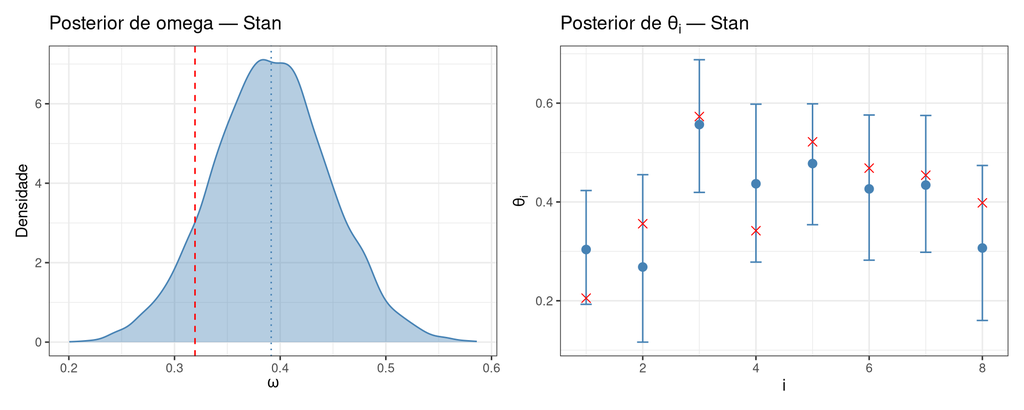

Figura 3

## Modelo não-hierárquico: $\omega$ e $\kappa$ fixados

Nesta seção, tanto $\omega$ quanto $\kappa$ são tratados como conhecidos. Os parâmetros $\alpha$ e $\beta$ ficam totalmente determinados:

$$\alpha = (\kappa - 2)\,\omega + 1, \qquad \beta = (\kappa - 2)\,(1 - \omega) + 1.$$

A única inferência é sobre cada $\theta_i$. A verossimilhança Binomial combinada com a priori $\text{Beta}(\alpha, \beta)$ produz uma posterior conjugada exata:

$$\theta_i \mid y_i \sim \text{Beta}(\alpha + y_i,\; \beta + n_i - y_i).$$

Usamos o valor verdadeiro simulado como $\omega$ fixado; na prática, seria um valor escolhido pelo analista.

```
     omega      alpha       beta
 0.3194048  6.7492860 13.2507140
```

### Analítico (exato)

A posterior conjugada permite calcular a média e os quantis diretamente, sem MCMC.

Estimativas posteriores dos $\theta_i$ — método analítico ($\omega$ fixo):

```
# A tibble: 8 × 7
      i   n_i   y_i theta_i mean_post  lower upper
  <int> <int> <int>   <dbl>     <dbl>  <dbl> <dbl>
1     1    46    12   0.205     0.284 0.183  0.398
2     2    10     0   0.356     0.225 0.0971 0.387
3     3    34    22   0.573     0.532 0.400  0.663
4     4    19     9   0.342     0.404 0.257  0.560
5     5    45    23   0.522     0.458 0.339  0.579
6     6    27    12   0.468     0.399 0.265  0.541
7     7    33    15   0.454     0.410 0.283  0.544
8     8    16     3   0.398     0.271 0.141  0.425
```

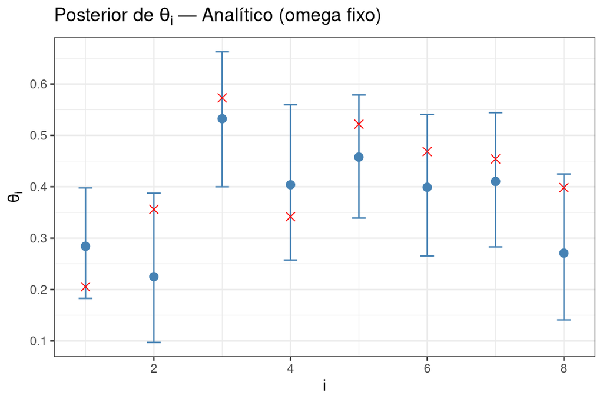

Figura 4

### JAGS ($\omega$ fixado)

Os parâmetros $\alpha$ e $\beta$ são passados diretamente como dados. O modelo contém apenas os $\theta_i$ como parâmetros.

Resumo das estatísticas posteriores (JAGS, $\omega$ fixo):

```
              Mean         SD     Naive SE Time-series SE
theta[1] 0.2833574 0.05481086 0.0004475288   0.0005624095
theta[2] 0.2258850 0.07391789 0.0006035370   0.0007903427
theta[3] 0.5332618 0.06730760 0.0005495642   0.0006891883
theta[4] 0.4037323 0.07782805 0.0006354634   0.0007929290
theta[5] 0.4586859 0.06116554 0.0004994146   0.0006203019
theta[6] 0.3987718 0.07020680 0.0005732362   0.0007138665
theta[7] 0.4103670 0.06717122 0.0005484507   0.0006960785
theta[8] 0.2698853 0.07245511 0.0005915935   0.0007598613
```

Estimativas posteriores dos $\theta_i$ (JAGS, $\omega$ fixo):

```
# A tibble: 8 × 7
      i   n_i   y_i theta_i mean_post  lower upper
  <int> <int> <int>   <dbl>     <dbl>  <dbl> <dbl>
1     1    46    12   0.205     0.283 0.180  0.395
2     2    10     0   0.356     0.226 0.0990 0.383
3     3    34    22   0.573     0.533 0.403  0.663
4     4    19     9   0.342     0.404 0.258  0.563
5     5    45    23   0.522     0.459 0.341  0.579
6     6    27    12   0.468     0.399 0.267  0.538
7     7    33    15   0.454     0.410 0.282  0.543
8     8    16     3   0.398     0.270 0.142  0.422
```

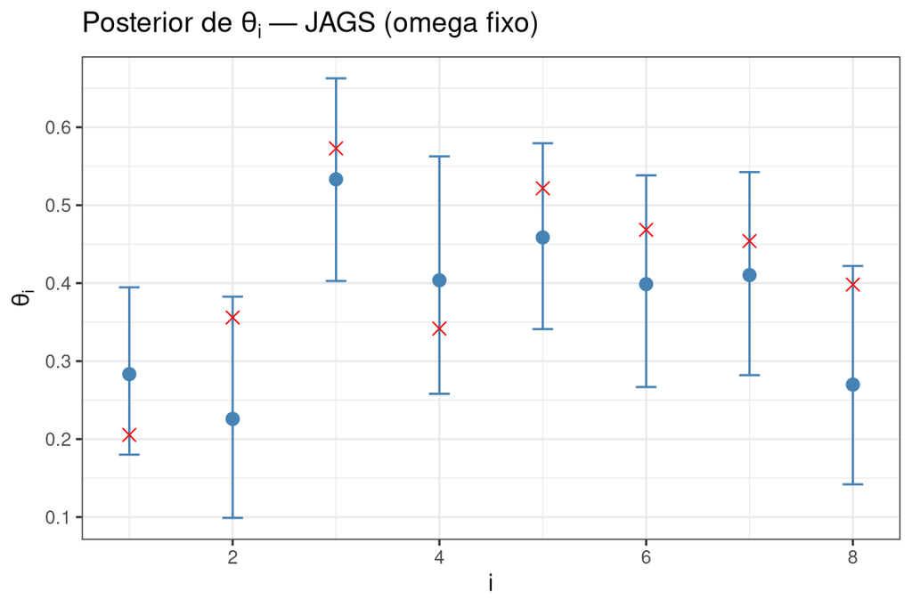

Figura 5

### Stan ($\omega$ fixado)

Nesta versão, $\omega$ é passado como dado escalar. Os valores $\alpha$ e $\beta$ são calculados no bloco `transformed data` e não há parâmetros populacionais a estimar.

Resumo dos $\theta_i$ (Stan, $\omega$ fixo):

```
Inference for Stan model: anon_model.
3 chains, each with iter=4000; warmup=1000; thin=1;
post-warmup draws per chain=3000, total post-warmup draws=9000.

         mean se_mean   sd 2.5%  25%  50%  75% 97.5% n_eff Rhat
theta[1] 0.28       0 0.06 0.18 0.25 0.28 0.32  0.40 14129    1
theta[2] 0.22       0 0.08 0.10 0.17 0.22 0.27  0.39 14727    1
theta[3] 0.53       0 0.07 0.40 0.49 0.53 0.58  0.67 14628    1
theta[4] 0.40       0 0.08 0.26 0.35 0.40 0.46  0.56 15095    1
theta[5] 0.46       0 0.06 0.34 0.42 0.46 0.50  0.58 14224    1
theta[6] 0.40       0 0.07 0.27 0.35 0.40 0.45  0.54 15592    1
theta[7] 0.41       0 0.07 0.28 0.36 0.41 0.46  0.54 14970    1
theta[8] 0.27       0 0.07 0.14 0.22 0.27 0.32  0.42 15045    1

Samples were drawn using NUTS(diag_e) at Wed Mar 25 21:15:20 2026.
For each parameter, n_eff is a crude measure of effective sample size,
and Rhat is the potential scale reduction factor on split chains (at
convergence, Rhat=1).
```

```
                 mean      se_mean         sd          2.5%          25%
theta[1]    0.2840216 0.0004640256 0.05515605    0.18295001    0.2458039
theta[2]    0.2247145 0.0006223695 0.07552862    0.09682611    0.1692605
theta[3]    0.5319673 0.0005621011 0.06798385    0.39771643    0.4869593
theta[4]    0.4046748 0.0006392682 0.07854163    0.25640519    0.3495960
theta[5]    0.4572172 0.0005072923 0.06050172    0.33973721    0.4157865
theta[6]    0.3996578 0.0005734591 0.07160769    0.26692281    0.3489548
theta[7]    0.4100763 0.0005534089 0.06771014    0.28129451    0.3629778
theta[8]    0.2706741 0.0005873602 0.07204465    0.13976635    0.2197837
lp__     -256.4277223 0.0319167013 2.04621577 -261.32928336 -257.5783996
                  50%          75%        97.5%     n_eff      Rhat
theta[1]    0.2823004    0.3199977    0.3972347 14128.710 0.9999925
theta[2]    0.2180354    0.2731862    0.3877040 14727.415 0.9999048
theta[3]    0.5327747    0.5776296    0.6652741 14627.923 0.9997815
theta[4]    0.4032495    0.4584911    0.5616540 15095.017 0.9997556
theta[5]    0.4563727    0.4979507    0.5779065 14223.910 0.9997365
theta[6]    0.3978312    0.4490095    0.5408636 15592.450 1.0000576
theta[7]    0.4089764    0.4560760    0.5426223 14969.772 1.0001664
theta[8]    0.2679950    0.3174830    0.4224905 15045.077 0.9999032
lp__     -256.0803095 -254.9231425 -253.4843524  4110.237 0.9998810
```

Estimativas posteriores dos $\theta_i$ (Stan, $\omega$ fixo):

```
# A tibble: 8 × 7
      i   n_i   y_i theta_i mean_post  lower upper
  <int> <int> <int>   <dbl>     <dbl>  <dbl> <dbl>
1     1    46    12   0.205     0.284 0.183  0.397
2     2    10     0   0.356     0.225 0.0968 0.388
3     3    34    22   0.573     0.532 0.398  0.665
4     4    19     9   0.342     0.405 0.256  0.562
5     5    45    23   0.522     0.457 0.340  0.578
6     6    27    12   0.468     0.400 0.267  0.541
7     7    33    15   0.454     0.410 0.281  0.543
8     8    16     3   0.398     0.271 0.140  0.422
```

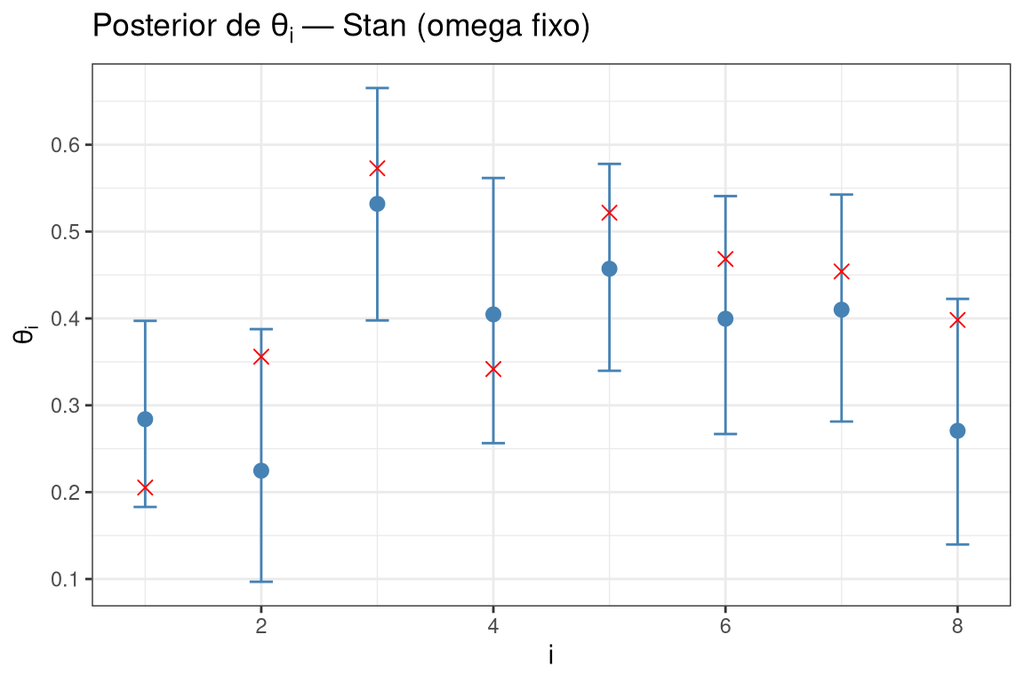

Figura 6

## Comparação entre métodos ($\omega$ fixo)

Os três métodos (Analítico, JAGS e Stan) produzem estimativas praticamente idênticas quando $\omega$ é fixado, confirmando a consistência entre a solução conjugada exata e as aproximações MCMC.

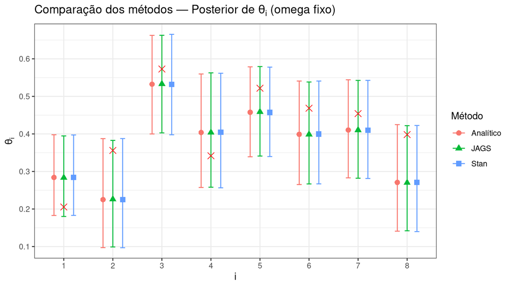

Figura 7

## Tabela consolidada e variâncias

```
# A tibble: 8 × 8
    n_i theta_i   y_i  prop theta_jags theta_anl_f theta_jags_f theta_g
  <int>   <dbl> <int> <dbl>      <dbl>       <dbl>        <dbl>   <dbl>
1    46   0.205    12 0.261      0.303       0.284        0.283   0.417
2    10   0.356     0 0          0.268       0.225        0.226   0.417
3    34   0.573    22 0.647      0.556       0.532        0.533   0.417
4    19   0.342     9 0.474      0.437       0.404        0.404   0.417
5    45   0.522    23 0.511      0.477       0.458        0.459   0.417
6    27   0.468    12 0.444      0.426       0.399        0.399   0.417
7    33   0.454    15 0.455      0.434       0.410        0.410   0.417
8    16   0.398     3 0.188      0.308       0.271        0.270   0.417
```

Variância de cada coluna — observar o efeito de *shrinkage* (encolhimento) nas estimativas hierárquicas em relação às proporções observadas:

```
            i           n_i       theta_i           y_i          prop
  6.000000000 174.214285714   0.013400050  66.285714286   0.043169117
   theta_jags    theta_stan   theta_anl_f  theta_jags_f  theta_stan_f
  0.009792479   0.009869601   0.010836502   0.010906021   0.010832560
      theta_g
  0.000000000
```

## Correlação entre estimativas

### Modelo com $\omega$ fixo

O gráfico de pares abaixo compara os verdadeiros $\theta_i$, as proporções amostrais $\hat{p}_i$ e as estimativas posteriores dos três métodos com $\omega$ fixado.

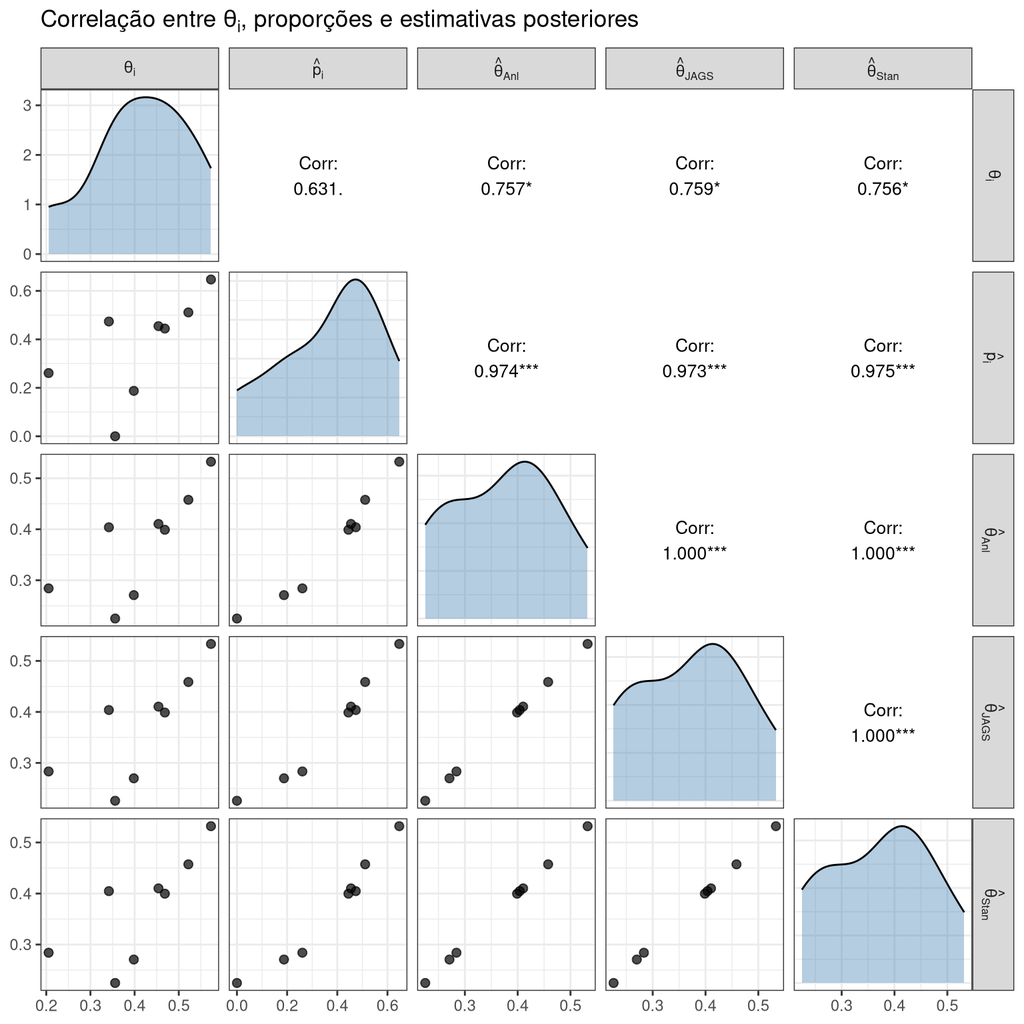

Figura 8

### Modelo fixo vs hierárquico

Comparação entre as estimativas do modelo com $\omega$ fixo (JAGS) e do modelo hierárquico (JAGS), evidenciando o efeito de *shrinkage* do modelo hierárquico.

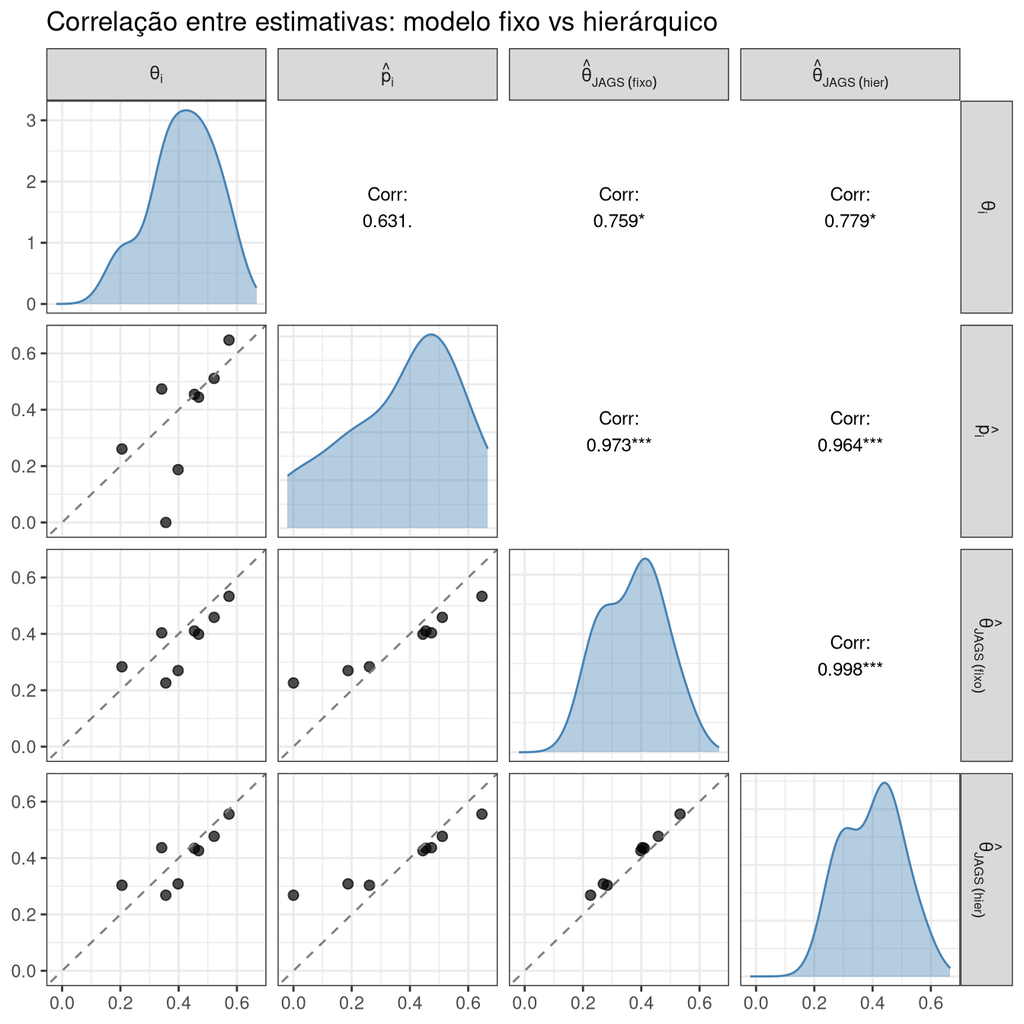

Figura 9

## Comparação final: fixo vs hierárquico vs proporção observada

O gráfico abaixo sintetiza as três abordagens. No modelo com $\omega$ fixo, cada $\theta_i$ é estimado independentemente. No modelo hierárquico, as estimativas são “puxadas” em direção à média global (*shrinkage*), especialmente para as observações com tamanho amostral menor. A proporção observada $\hat{p}_i$ não incorpora informação da priori.

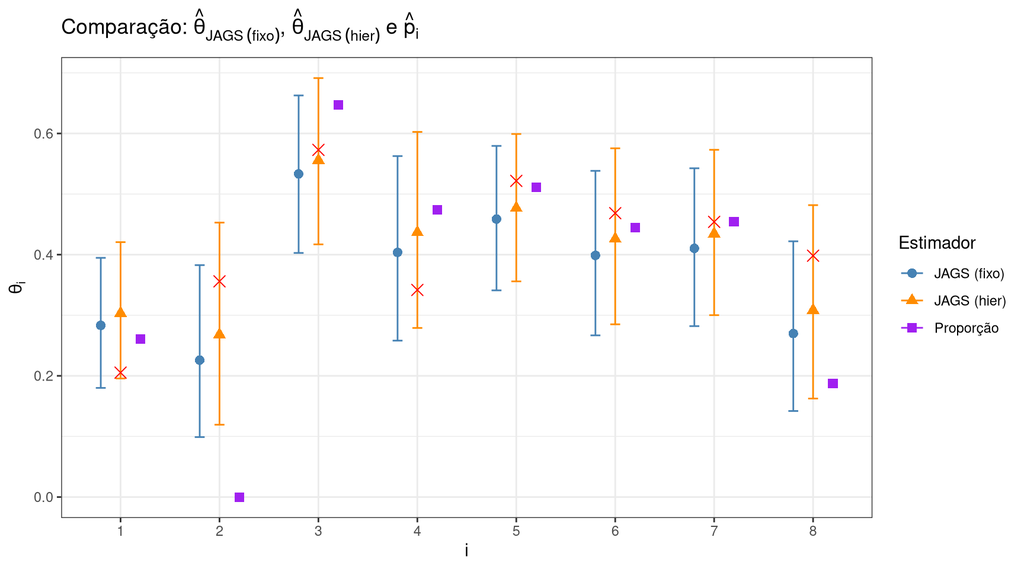

Figura 10